# Automating Inflation Calculations in Google Sheets

Using the ImportXML and CPI’s Inflation Calculator

Matt Worthington

2017-06-22

Hey y’all, as I was working on a historical data set on School Finance this past week and came across a flawed, albeit enlightening article on automating inflation calculations on historical for large, historical datasets. The formula had parsing errors that were fixable by adding a concatenate function. Anyway, passing it along in case others want to use it.

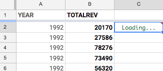

Figure 1 - Sample Historical Data

## Step 1: Load Your Data In The Proper Columns and Add Headers.

Looking at the image above in Figure 1, load only years in `Column A` & your historical financial figures in `Column B`. Assuming you’re using headers in the first row, copy & paste the formula below in `Cell C2`.

```
=IMPORTXML("https://data.bls.gov/cgi-bin/cpicalc.pl?" &
CONCATENATE("cost1=",B2,"&year1=",A2,"01&year2=",YEAR(TODAY()),"0",MONTH(DATE(2017,5,20))), "//span[@id='answer']")
```

## Step 2: If Needed, Replace Cells For Dates You’re Adjusting To

The only caveat is that you’ll need to replace the dates for `TODAY()` & `DATE(2017,5,20))` with whatever date you’re adjusting for. In case, I’m adjusting to the latest calculations that the Bureau of Labor Statistics has made available through their CPI Calculator. If that’s what you’re adjusting for, then the current formula works as is. If your dates and figures are in columns other than `Column A` & `Column B`, you’ll need to adjust the `B2` & `A2` values in the formula above. Otherwise, it’ll work as it is written above.

## Step 3: Copy Down For All Rows With Data & Wait.

Then just copy down for all rows that needed to be adjusted for inflation. Just to expect to wait a while if you’re loading queries for hundreds of data points.